# DAPR3 assessed group report – Instructions and FAQs

Academic year 2026/27

Your group’s task is to develop a statistical analysis and write a report to address the research question that will be published in Week 3 of the course (w/c 5 October 2026). You must use the data provided and the methods you learn in DAPR3.

In this document, you will find answers to many of the questions you may have about group work, the format of the report, AI use, etc.

In Week 3, you will receive specific details about your analysis task (that is, we’ll give you data, tell you about the study context, and outline the research question(s) you will investigate).

# About group work

## When will groups be formed?

We will allocate everybody to a group during Week 3 of the course.

## How will groups be formed?

We’ll form groups by maximising the diversity of each group member’s data analysis skills.

To this end, at the beginning of Week 3, we’ll ask you to fill in a short survey in which you’ll rank which data analysis skills you’re best at. We’ll use these rankings to create groups of maximum five people with complementary skillsets.

If you don’t fill out this form in time, we’ll allocate you to a group at random.

This process means that you’ll likely end up working with people you haven’t met before. We know that this can be uncomfortable, at least at the beginning. Approach it as an opportunity to develop your teamwork, collaboration, and leadership skills.

**Important:** It’s unlikely that all group members will be in the same lab session as you. The expectation is that you coordinate your work on the report **outside of the timetabled lab sessions.**

## How should I coordinate with my group?

At the end of Week 3, once groups have been formed and the report task released, we will provide each group with a group discussion space on Learn as well as the names and emails of all members. You can then coordinate your project however you like.

You are expected to **work together** on the project. This collaboration may be synchronous or asynchronous, but either way, regular check-ins and messaging will be crucial.

How your group arranges to complete the project is entirely up to you. You may decide to meet up and work together, or allocate different parts of the project to different people (and then swap, to review/polish as necessary), or focus on different “skills” (coding, plots, interpretation, writing, etc.). **Regardless, everyone in the group is expected to contribute.**

When collaboration works well, you can expect a Gestalt effect: the whole is greater than the sum of its parts, or in other words, the group will produce better work than any one person could have achieved individually.

## Experiencing problems in your group?

We hope this doesn’t happen to you, but if it does, here’s what to do.

**As soon as possible, please contact the course teaching team at ppls.psych.stats@ed.ac.uk.** and let us know what the problem is so we can try to help.

Please also remember that part of the purpose of peer-adjustment (see the section below), is to incorporate group contributions into the marks.

**NoteWhat if someone in my group isn’t contributing at all?**

- If you haven’t heard from a groupmate at all after one week, despite your attempts to contact and include them, then please let us know so that we can get in touch with them while there is still time.
- If a groupmate has not contributed to the report at all by the time you submit, even though they had the opportunity to do so, then you can leave their exam number off of your final submission and give them all 0s in their peer assessment (for details about submission and peer assessment, see below). Please ensure you have consensus in the remaining group members about taking this step.

Any student whose exam number is not listed in their group’s submission and who receives all 0s in their peer assessments will be invited to a meeting with the course organiser. If they cannot explain the group’s approach to collaboration (including their own contributions to the project) and the thinking and reasoning that went into the analysis and write-up, then their final mark for the report will be a 0.

# About the report itself

## When is the report due?

- **Weighting:** The report is worth 30% of your final course grade.
- **Released:** Thursday 8 October 2026 at 12 noon
- **Due:** Thursday 29 October 2026 at 12 noon

We designed this project to be doable within 14 days, and all students have been given up to 21 days. By giving everybody 21 days, we apply any extra time requirements, which should ensure that everybody has enough time to complete the task (in other words, extra time for groupwork has been [mainstreamed](https://disability-learning-support-service.ed.ac.uk/staff/adjustments/mainstreaming-adjustments)). Therefore, we will not consider any additional extra time adjustments.

## What do we submit?

Each group must submit **two files:**

1. an **.Rmd** file that generates the exact analysis presented in your report
2. the written report itself in **.pdf** format which contains no R code (ideally the result of knitting the Rmd file you submit)

**The name of each file should be your group name followed by the appropriate file extension.** For example, the group “Cranium Collective” would submit two files:

- `CraniumCollective.pdf` AND
- `CraniumCollective.Rmd`

**Only one person in each group needs to submit your group’s files.**

(If your submission files are not in these formats and we therefore cannot open them, we will unfortunately have to give you a grade of zero for the report.)

You *can* submit your report late, but late submissions will be penalised by removing five marks for every day that they’re late (see the PPLS late penalty policy).

## How do we submit?

You’ll be able to submit your report via the DAPR3 Learn page, under Assessments > Report (Group Based). There you will see two links, one labelled “Group Report PDF file” the other “Group Report code file”. Please upload each file in the appropriate place.

In the “Submission Title” field, enter your group name. For example, the Cranium Collective group would enter the following:

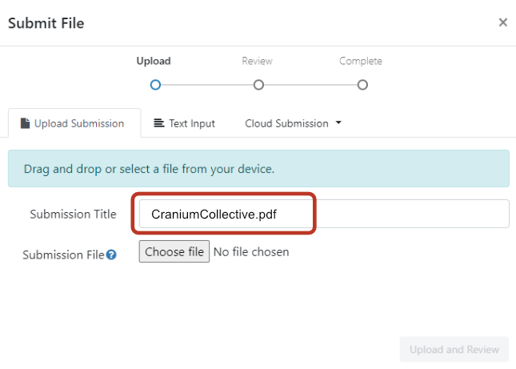

If you have any technical issues with the Turnitin submission, please contact the Teaching Office (ppls.ugteaching@ed.ac.uk) and CC the PPLS Psych Stats email address (ppls.psych.stats@ed.ac.uk).

## What should go into the report?

### The write-up

The written report should read like the Results section of a journal article: enough detail that someone else can understand your analysis choices and replicate your analysis in any statistical software. Approach it following the same principles that you’ve used in approaching write-ups in DAPR2, and don’t forget [the reporting mixed effects model analyses flashcard](https://uoepsy.github.io/dapr3/2627/flashcards/block1/reporting.html).

**We encourage you to use the helpful report template we’ve prepared.** You can download it by clicking here: dapr3_2627_report_template.Rmd. You can write all your code and text in that template, and then you can knit the document to PDF to generate the written report PDF file.

If that doesn’t spark joy, then it’s fine to write the text of the report in a separate word processor like Microsoft Word or Google Docs. Just make sure it’s exported to PDF format for submission.

**VERY IMPORTANT:** Except for the appendix/appendices, we will not read or mark any content after the fourth page.

For writing and formatting in RMarkdown, you may find these resources helpful:

- [DAPR1 formatting resources](https://uoepsy.github.io/dapr1/2526/labs/zf_formatting_resources.html)
- [uoepsy Rmd bootcamp](https://uoepsy.github.io/scs/rmd-bootcamp)
- [RMarkdown cheat sheet](https://rmarkdown.rstudio.com/lesson-15.HTML)
- [Writing math in Rmd](https://rpruim.github.io/s341/S19/from-class/MathinRmd.html#:~:text=Math%20inside%20RMarkdown,10n%3D1n2.)

**Knitting Rmd to PDF**

Please note that to knit Rmd directly to PDF, you should:

1. Make sure the tinytex package is installed.
2. Makes sure the `yaml` header (the bit at the very top of your document) looks something like this.
   - In the `title` line, replace `(Cranium Collective)` with your actual group name.
   - In the `author` line, write the exam number of each individual who contributed to the report.

```
---
title: "DAPR3 2026/27 group report (Cranium Collective)"
author: "B000001, B000002, B000003, B000004, B000005"
date: "YYYY-MM-DD"
output:
  bookdown::pdf_document2:
    toc: false
---
```

**If you cannot knit directly to PDF, then try the following steps:**

1. Knit to HTML
2. Open your HTML file in a web browser (e.g. Chrome, Firefox)
3. Print the web page to PDF (Ctrl+P or Cmd+P, then choose to save to PDF)
4. Submit the PDF you just saved.

### The code

You must write your code in R and submit it as an Rmd file.

We want to see your code so that we can assess the reproducibility of your work. The code you submit should successfully conduct the analysis you describe and return the exact results, figures, and tables that are detailed in your report.

Unfortunately there are no straightforward ways to collaboratively edit Rmd files. We suggest that each group nominate one person to hold the “main copy” of the script, the version that will be submitted. This minimises the risk of different versions floating around. (Alternatively, if you want to get really fancy with version control, your group could try out [git and GitHub](https://docs.github.com/en/get-started/start-your-journey).)

## How long can the report be?

The main body of the report, not including the appendix/appendices, should be a **maximum of four sides of A4** using RStudio’s default formatting and font settings.

**VERY IMPORTANT:** Except for the appendix/appendices, we will not read or mark any content after the fourth page.

# About assessment and feedback

## How will the report be assessed?

### First, a group mark

- We’ll assess the report based on the specifications given in dapr3_2627_report_rubric_UPDATED.xlsx (click to download).
  - **PLEASE NOTE THAT THIS HAS BEEN UPDATED RUBRIC DUE TO STRIKE ACTION.** (The old version can be found [here](https://uoepsy.github.io/dapr3/2627/report/dapr3_2627_report_rubric.xlsx)).
- For each specification, we will evaluate whether it is
  - clearly evident in your report (worth 3 points),
  - mostly evident (2 points),
  - minimally/vaguely evident (1 point), or
  - not yet evident (0 points).
- We will add up the scores within each category of specifications, and then weight them by the relative importance of each category (indicated as percentages on the second sheet of the attached rubric).
- After adding up these weighted scores, the result will be a weighted average of how evident each specification is in your report.
- We will round this weighted average to the nearest value on the [Psychology 20-point marking scale](https://uoe.sharepoint.com/sites/hss/ppls/PPLS-Undergraduate-Student-Hub-home/SitePages/Psychology-marking-information.aspx#marking-policy-in-psychology).
- This will be the group mark for the report.

**VERY IMPORTANT:** Except for the appendix/appendices, we will not read or mark any content after the fourth page.

### Next, peer adjustment

Your groupmates have a better sense than we do about how much each person contributed to the report project. With peer adjustments, we can incorporate a measure of each person’s contribution into their mark.

After submitting the report, every member of your group will be asked to complete the peer assessment. You will be asked to assess, for yourself and each of your groupmates, how much each person contributed relative to the group as a whole. If someone made an average contribution in a given area, you should award that person the middle score. If they contributed substantially more than average, you would give a higher mark; if they genuinely contributed less, you might choose a lower mark. (If you don’t contribute any peer adjustment marks, the relative weight of the group members who do complete the peer assessment will be higher.)

The adjustments for each group member are scaled, then averaged together, then used as “weights” to adjust the overall group mark. You can play around with the live demo of this system at https://uoe-psy.shinyapps.io/peer_adj/.

**Peer assessment ratings can adjust grades by up to 20% of the report mark.**

The peer assessment will take place through Learn, after the deadline for the report submission. We will send an announcement when it is available for completion.

## What kind of feedback will we get?

You will get a spreadsheet that contains the filled-in rubric for your group’s report. You will also get an annotated copy of your submitted PDF where we note where we see evidence for each specification from the rubric (or if we don’t see evidence of it, where that evidence would have fit).

# Can we use generative/agentic AI for this report?

No. Using generative/agentic AI for any part of this assessment is not permitted.

You already have all the tools and information you need to succeed. You can use:

- the DAPR3 lecture materials,
- the lab materials,
- the flash cards,
- your groupmates, and
- us, the teaching team!

# More questions? Piazza!

If you have questions about the report that go beyond the information laid out here, then **please post them on Piazza (accessible from Learn), using the folder “report”.**

You can ask questions on Piazza at any time.

**Important: Any question that’s posted before Wednesday 28 October at 12 noon (24 hours before the project deadline) will get an answer. Questions posted within 24 hours of the deadline may not get an answer.**

Why Piazza instead of email? Because we want to make sure that everybody in the course has access to all the same information, which is not the case when we answer individual emails. So please don’t send us report questions by email—we’ll just direct you to Piazza :)